# Add Field Note Flags

ROSSyndicate

2023-11-01

# 1 `add_field_flag()`

This function adds three flags:

1. `"sonde not employed"`
2. `"site visit"`
3. `"sv window"`

These flags are determined using the field notes that staff take when they are servicing the sondes.

```r
add_field_flag <- function(df) {
  df <- df %>%
    # flag when sonde was not employed in the river
    add_flag(sonde_employed == 1, "sonde not employed") %>%
    # flag when sonde was handled in a site visit
    add_flag(as.character(last_site_visit) == as.character(DT_round), "site visit") %>%
    # Add flags for the next 45 minutes after a site visit
    add_flag(lag(str_detect(flag, "site visit"), n = 3), "sv window") %>%
    add_flag(lag(str_detect(flag, "site visit"), n = 2), "sv window") %>%
    add_flag(lag(str_detect(flag, "site visit"), n = 1), "sv window")
  return(df)
}
```

## 1.1 Add `"sonde not employed"` flag.

**The sonde not employed flag is triggered when the `sonde_employed` column is equal to one. The `sonde_employed` column is generated in the `clean_field_notes` function and uses the `sensor_pulled` and `sensor_deployed` columns from the original field notes**

```r
add_flag(sonde_employed == 1,
         "sonde not employed")
```

- `sonde_employed` = Binary result from the `clean_field_notes()` step in the pipeline.
- `"sonde not employed"` = Flag descriptor inserted into the `flag` column.

## 1.2 Add `"site visit"` flag.

**The site visit flag is triggered when the `last_site_visit` column is equal to the `DT_round` column. The `last_site_visit` column is created during the `clean_field_notes()` step, and is filled during the `summarize_site_param()` step, after it has been joined to the HydroVu API data.**

```r
add_flag(as.character(last_site_visit) == as.character(DT_round),
         "site visit")
```

# 2 Add `"sv window flag"` flag.

**The sv window flag is triggered if the `"site visit"` flag is detected within the previous three data points.**

```r
add_flag(lag(str_detect(flag, "site visit"), n = [1/2/3]),
         "sv window")
```

# 3 Analysis

| Site | Parameter | Flag | % of Total Data Points Flagged | % of Total Dates Flagged |
| --- | --- | --- | --- | --- |
| archery | Actual Conductivity | sonde not employed | 58.61 | 43.80 |
| archery | Actual Conductivity | site visit | 0.17 | 11.53 |
| archery | Actual Conductivity | sv window | 0.49 | 11.53 |
| archery | Chl-a Fluorescence | sonde not employed | 55.28 | 41.99 |
| archery | Chl-a Fluorescence | site visit | 0.16 | 11.05 |
| archery | Chl-a Fluorescence | sv window | 0.47 | 11.05 |
| archery | Depth | sonde not employed | 69.03 | 48.25 |
| archery | Depth | site visit | 0.20 | 12.70 |
| archery | Depth | sv window | 0.58 | 12.70 |
| archery | DO | sonde not employed | 69.03 | 49.84 |
| archery | DO | site visit | 0.20 | 13.11 |
| archery | DO | sv window | 0.58 | 13.11 |
| archery | ORP | sonde not employed | 68.30 | 44.19 |
| archery | ORP | site visit | 0.19 | 11.63 |
| archery | ORP | sv window | 0.57 | 11.63 |
| archery | pH | sonde not employed | 66.68 | 43.30 |
| archery | pH | site visit | 0.19 | 11.40 |
| archery | pH | sv window | 0.56 | 11.40 |
| archery | Specific Conductivity | sonde not employed | 68.05 | 46.63 |
| archery | Specific Conductivity | site visit | 0.19 | 12.27 |
| archery | Specific Conductivity | sv window | 0.57 | 12.27 |
| archery | Temperature | sonde not employed | 68.62 | 42.34 |
| archery | Temperature | site visit | 0.20 | 11.14 |
| archery | Temperature | sv window | 0.58 | 11.14 |
| archery | Turbidity | sonde not employed | 50.65 | 47.06 |
| archery | Turbidity | site visit | 0.09 | 8.05 |
| archery | Turbidity | sv window | 0.27 | 8.05 |
| boxelder | Actual Conductivity | sonde not employed | 75.30 | 52.71 |
| boxelder | Actual Conductivity | site visit | 0.16 | 10.47 |
| boxelder | Actual Conductivity | sv window | 0.47 | 10.47 |

[output cut: 136 more lines]

# 4 Examples:

## 4.1 sonde not employed

### 4.1.1 Good

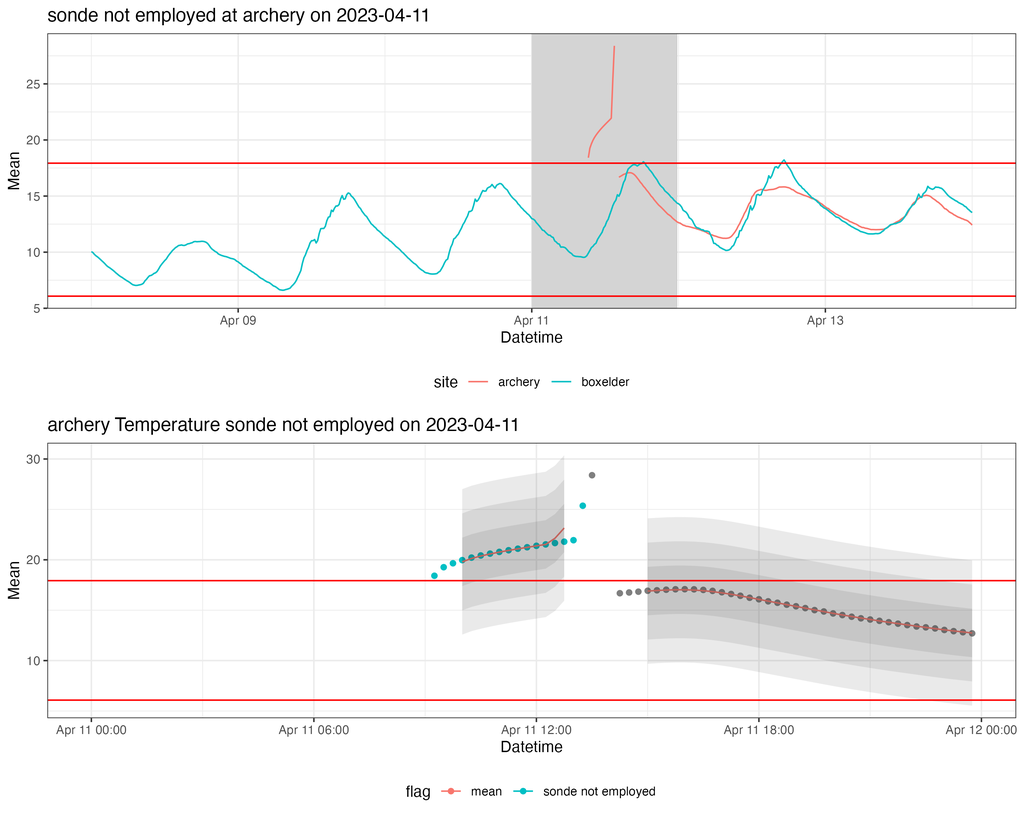

- The log was started when the sonde was out of the water, and in the field notes we wrote down when it went into the water.

## 4.2 site visit

### 4.2.1 Good

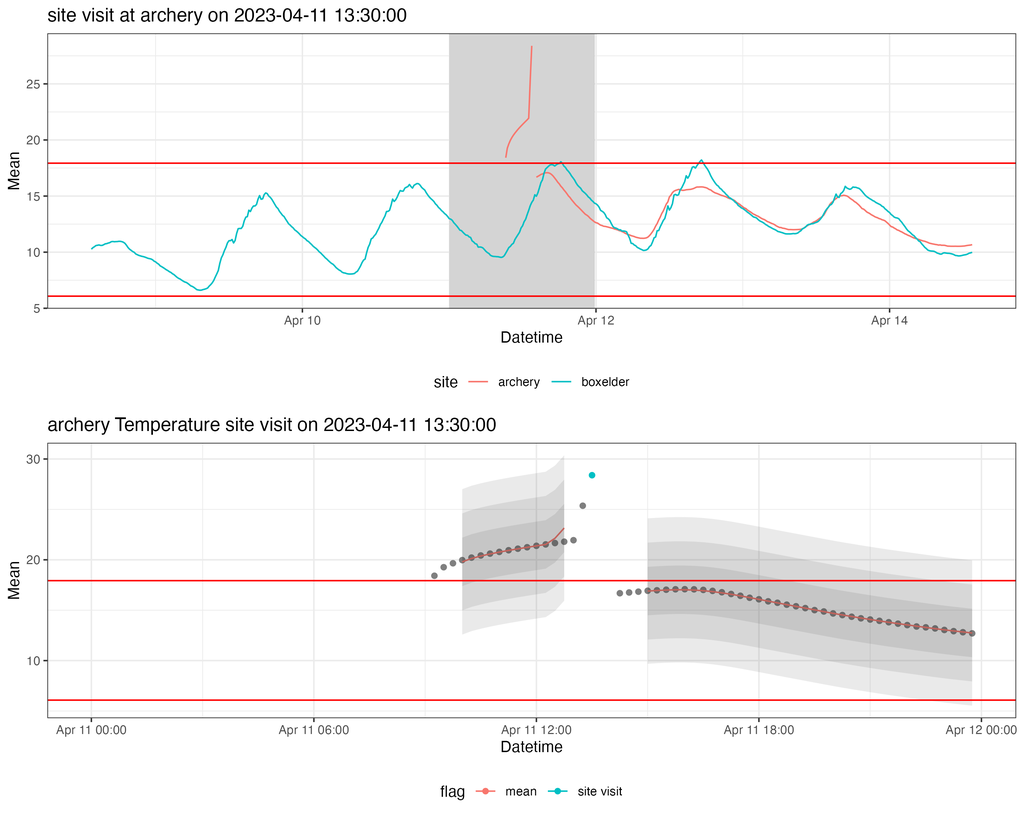

- We can see the data acting strange in relation to the information that we have in our field notes.

## 4.3 sv window

### 4.3.1 Good

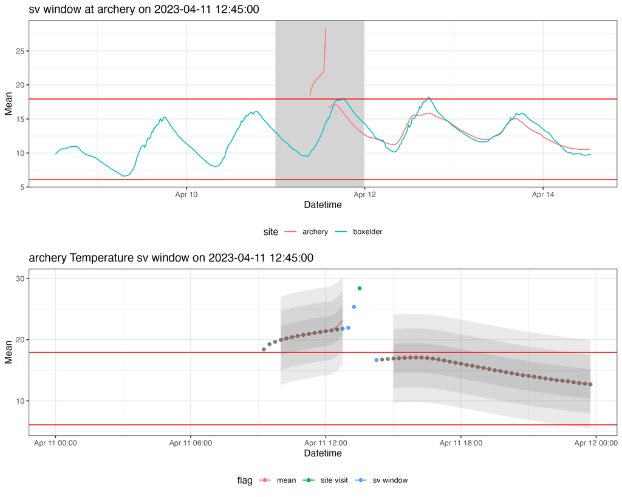

- We can see the data acting strange in relation to the information that we have in our field notes. - The data points surrounding the site visit were also flagged.